# cosmology

```python
import numpy as np
import matplotlib.pyplot as plt
```

## 1. Densities as a function of redshift

*Author: Nicholas Faucher*

Plot $Ω_m(z)$ and $Ω_Λ(z)$ between $z = 0$ and $5$, for a flat Universe, assuming $Ω_m(z = 0) = 0.3$.

We start with the definitions:

$Ω_k = \frac{2E}{m H^2a^2(t)r^2}$

$Ω_m = \frac{8 \pi G \rho}{3H^2}$

$Ω_\Lambda = \frac{\Lambda}{3H^2}$

which satisfy the condition

$Ω_k + Ω_m + Ω_\Lambda = 1$.

For a flat Universe, $E = 0$, allowing us to simplify the above equations

$Ω_k = 0$

$Ω_m + Ω_\Lambda = 1$.

In order to get $Ω_k$ and $Ω_m$ as a function of redshift z, we must relate the Hubble parameter $H$ to the redshift. Hogg (1999) relates these two parameters in the following way:

$H(z) = H_0 E(z)$

$E(z)=\sqrt{Ω_{m,0}(1+z)^3+Ω_{k,0}(1+z)^2+Ω_{\Lambda,0}}$

where a $0$ in the subscript indicates the value of the parameter at $z=0$. Recalling that for a flat universe $Ω_k=0$ for all redshifts, the relations above simplify to

$H(z) = H_0 \sqrt{Ω_{m,0}(1+z)^3+Ω_{\Lambda,0}}$

With $Ω_{m,0} = 0.3$, $\Omega_{\Lambda, 0} = 0.7$ to satisfy the relation $Ω_{m,0} + Ω_{\Lambda,0} = 1$.

We can now use the equation above for $E(z)$, because:

$\Omega_\Lambda = \frac{\Omega_{\Lambda 0}}{E^2(z)}$

Using the relation $Ω_m + Ω_\Lambda = 1$ gives us the solution for $Ω_m$ as well.

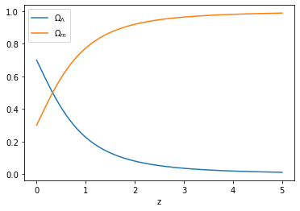

```python
z = np.linspace(0,5,num=100)

omega_lam0 = 0.7
omega_m0 = 1. - omega_lam0

E_z = (omega_m0 * (1 + z)**3 + omega_lam0)**(1/2)

omega_lam = omega_lam0 / (E_z**2)
omega_m = 1. - omega_lam

plt.plot(z, omega_lam, label="$\Omega_{\Lambda}$")
plt.plot(z, omega_m, label="$\Omega_{m}$")
plt.legend()
plt.xlabel('z')
plt.show()
```